# Bitcoin_Regression

Colton Manning

8/22/2021

## Loading data

```r
set.seed(19970101)
library(readr)
BTC_data = read_csv("/Users/coltonmanning/OneDrive/Documents/Portfolio Projects/Bitcoin Twitter Sentiment Analysis/Cleaned_Data/final.csv")
BTC_data = na.omit(BTC_data)
head(BTC_data)
```

```
## # A tibble: 6 x 14
##      X1 date        Open Close price_change Percent_Change price_chng_max_abs_s…
##   <dbl> <date>     <dbl> <dbl>        <dbl>          <dbl>                 <dbl>
## 1     0 2016-01-01  431.  434.        2.93         0.00680                -0.176
## 2     1 2016-01-02  435.  434.       -1.32        -0.00304                -0.176
## 3     2 2016-01-03  433.  431.       -2.16        -0.00499                -0.176
## 4     3 2016-01-04  432.  434.        2.63         0.00609                -0.176
## 5     4 2016-01-05  433.  432.       -0.880       -0.00203                -0.176
## 6     5 2016-01-06  432.  430.       -2.89        -0.00668                -0.177
## # … with 7 more variables: negative <dbl>, neutral <dbl>, positive <dbl>,
## #   percent_neg <dbl>, percent_neu <dbl>, percent_pos <dbl>,
## #   price_increase_next_day <lgl>
```

```r
BTC_data[is.na(BTC_data)]
```

```
## <unspecified> [0]
```

```r
str(BTC_data)
```

```
## tibble [1,390 × 14] (S3: tbl_df/tbl/data.frame)
##  $ X1                      : num [1:1390] 0 1 2 3 4 5 6 7 8 9 ...
##  $ date                    : Date[1:1390], format: "2016-01-01" "2016-01-02" ...
##  $ Open                    : num [1:1390] 431 435 433 432 433 ...
##  $ Close                   : num [1:1390] 434 434 431 434 432 ...
##  $ price_change            : num [1:1390] 2.93 -1.32 -2.16 2.63 -0.88 ...
##  $ Percent_Change          : num [1:1390] 0.0068 -0.00304 -0.00499 0.00609 -0.00203 ...
##  $ price_chng_max_abs_scale: num [1:1390] -0.176 -0.176 -0.176 -0.176 -0.176 ...
##  $ negative                : num [1:1390] 32 39 36 38 36 35 42 39 35 21 ...
##  $ neutral                 : num [1:1390] 322 222 142 165 122 157 256 295 259 233 ...
##  $ positive                : num [1:1390] 38 17 3 5 4 3 7 46 20 9 ...
##  $ percent_neg             : num [1:1390] 0.0816 0.1403 0.1989 0.1827 0.2222 ...
##  $ percent_neu             : num [1:1390] 0.821 0.799 0.785 0.793 0.753 ...
##  $ percent_pos             : num [1:1390] 0.0969 0.0612 0.0166 0.024 0.0247 ...
##  $ price_increase_next_day : logi [1:1390] FALSE FALSE TRUE FALSE FALSE TRUE ...
##  - attr(*, "na.action")= 'omit' Named int [1:33] 14 98 113 122 155 157 162 186 194 201 ...
##   ..- attr(*, "names")= chr [1:33] "14" "98" "113" "122" ...
```

### Setting up train/test data

```r
train_idx = sample(nrow(BTC_data), size = nrow(BTC_data) * 0.8)

BTC_train = BTC_data[train_idx, ]
BTC_test = BTC_data[-train_idx, ]
```

> We will train the model on 80% of the data and test it on the other 20%

## Creating models

### Let’s create a few simple models to start with

```r
glm1 = glm(price_increase_next_day ~ percent_neg +  percent_pos + date + price_chng_max_abs_scale, data = BTC_train, family = binomial)
summary(glm1)
```

```
##
## Call:
## glm(formula = price_increase_next_day ~ percent_neg + percent_pos +
##     date + price_chng_max_abs_scale, family = binomial, data = BTC_train)
##
## Deviance Residuals:
##    Min      1Q  Median      3Q     Max
## -1.408  -1.246   1.005   1.095   1.377
##
## Coefficients:
##                            Estimate Std. Error z value Pr(>|z|)
## (Intercept)               3.4612877  3.5404393   0.978    0.328
## percent_neg              -1.8354124  1.1161478  -1.644    0.100
## percent_pos               0.4402191  0.7470927   0.589    0.556
## date                     -0.0001989  0.0002100  -0.947    0.344
## price_chng_max_abs_scale -1.7206310  1.2717851  -1.353    0.176
##
## (Dispersion parameter for binomial family taken to be 1)
##
##     Null deviance: 1528.6  on 1111  degrees of freedom
## Residual deviance: 1521.5  on 1107  degrees of freedom
## AIC: 1531.5
##
## Number of Fisher Scoring iterations: 4
```

```r
glm2 = glm(price_increase_next_day ~ negative + neutral + positive + date + price_change, data = BTC_train, family = binomial)
summary(glm2)
```

```
##
## Call:
## glm(formula = price_increase_next_day ~ negative + neutral +
##     positive + date + price_change, family = binomial, data = BTC_train)
##
## Deviance Residuals:
##    Min      1Q  Median      3Q     Max
## -1.452  -1.264   1.036   1.077   1.367
##
## Coefficients:
##                Estimate Std. Error z value Pr(>|z|)
## (Intercept)   3.417e+00  3.129e+00   1.092    0.275
## negative     -3.542e-04  2.624e-04  -1.350    0.177
## neutral      -1.777e-05  3.276e-05  -0.542    0.588
## positive      1.266e-04  9.484e-05   1.334    0.182
## date         -1.814e-04  1.795e-04  -1.010    0.312
## price_change -2.543e-04  1.984e-04  -1.282    0.200
##
## (Dispersion parameter for binomial family taken to be 1)
##
##     Null deviance: 1528.6  on 1111  degrees of freedom
## Residual deviance: 1522.5  on 1106  degrees of freedom
## AIC: 1534.5
##
## Number of Fisher Scoring iterations: 4
```

```r
glm3 = glm(price_increase_next_day ~ negative + neutral + positive + date + Open + Close, data = BTC_train, family = binomial)
summary(glm3)
```

```
##
## Call:
## glm(formula = price_increase_next_day ~ negative + neutral +
##     positive + date + Open + Close, family = binomial, data = BTC_train)
##
## Deviance Residuals:
##    Min      1Q  Median      3Q     Max
## -1.453  -1.266   1.028   1.069   1.458
##
## Coefficients:
##               Estimate Std. Error z value Pr(>|z|)
## (Intercept) -3.178e-01  3.905e+00  -0.081    0.935
## negative    -3.196e-04  2.623e-04  -1.218    0.223
## neutral     -1.863e-05  3.323e-05  -0.561    0.575
## positive     1.195e-04  9.505e-05   1.257    0.209
## date         4.132e-05  2.272e-04   0.182    0.856
## Open         2.342e-04  1.987e-04   1.179    0.238
## Close       -2.694e-04  1.987e-04  -1.356    0.175
##
## (Dispersion parameter for binomial family taken to be 1)
##
##     Null deviance: 1528.6  on 1111  degrees of freedom
## Residual deviance: 1519.9  on 1105  degrees of freedom
## AIC: 1533.9
##
## Number of Fisher Scoring iterations: 4
```

```r
glm4 = glm(price_increase_next_day ~ percent_neg +  percent_pos + Percent_Change, data = BTC_train, family = binomial)
summary(glm4)
```

```
##
## Call:
## glm(formula = price_increase_next_day ~ percent_neg + percent_pos +
##     Percent_Change, family = binomial, data = BTC_train)
##
## Deviance Residuals:
##     Min       1Q   Median       3Q      Max
## -1.5634  -1.2552   0.9862   1.0858   1.4640
##
## Coefficients:
##                Estimate Std. Error z value Pr(>|z|)
## (Intercept)     0.44499    0.16477   2.701  0.00692 **
## percent_neg    -2.43985    1.03843  -2.350  0.01880 *
## percent_pos     0.01667    0.56248   0.030  0.97636
## Percent_Change -4.20541    1.54272  -2.726  0.00641 **
## ---
## Signif. codes:  0 '***' 0.001 '**' 0.01 '*' 0.05 '.' 0.1 ' ' 1
##
## (Dispersion parameter for binomial family taken to be 1)
##
##     Null deviance: 1528.6  on 1111  degrees of freedom
## Residual deviance: 1516.7  on 1108  degrees of freedom
## AIC: 1524.7
##
## Number of Fisher Scoring iterations: 4
```

```r
glm5 = glm(price_increase_next_day ~ percent_neg +  percent_pos + date + Percent_Change, data = BTC_train, family = binomial)
summary(glm5)
```

```
##
## Call:
## glm(formula = price_increase_next_day ~ percent_neg + percent_pos +
##     date + Percent_Change, family = binomial, data = BTC_train)
##
## Deviance Residuals:
##     Min       1Q   Median       3Q      Max
## -1.5564  -1.2434   0.9763   1.0932   1.4702
##
## Coefficients:
##                  Estimate Std. Error z value Pr(>|z|)
## (Intercept)     3.9732881  3.5387221   1.123  0.26152
## percent_neg    -2.0210033  1.1211086  -1.803  0.07144 .
## percent_pos     0.5099729  0.7493930   0.681  0.49618
## date           -0.0002101  0.0002105  -0.998  0.31819
## Percent_Change -4.2265649  1.5440663  -2.737  0.00619 **
## ---
## Signif. codes:  0 '***' 0.001 '**' 0.01 '*' 0.05 '.' 0.1 ' ' 1
##
## (Dispersion parameter for binomial family taken to be 1)
##
##     Null deviance: 1528.6  on 1111  degrees of freedom
## Residual deviance: 1515.7  on 1107  degrees of freedom
## AIC: 1525.7
##
## Number of Fisher Scoring iterations: 4
```

### Variance inflation factor

We will now check for collinearity in our models. We expect there to be several collinear variables in our models considering some of our predictors are transformations of each other (e.g. `price_change`, `Percent_Change`, `price_chng_max_abs_scale`) We will consider any inflation factor $> 5$ to be large

```r
vif(glm1)
```

```
##              percent_neg              percent_pos                     date
##                 4.848492                 7.298878                 8.201391
## price_chng_max_abs_scale
##                 4.149497
```

```r
vif(glm2)
```

```
##     negative      neutral     positive         date price_change
##   236.478966    76.750182   320.150436     5.990145     4.156813
```

```r
vif(glm3)
```

```
##   negative    neutral   positive       date       Open      Close
## 236.319076  78.977691 321.546816   9.594396 685.222270 685.663026
```

```r
vif(glm4)
```

```
##    percent_neg    percent_pos Percent_Change
##       4.196835       4.137371       4.297333
```

```r
vif(glm5)
```

```
##    percent_neg    percent_pos           date Percent_Change
##       4.891687       7.343893       8.236752       4.304850
```

### Removing collinear predictors

```r
glm1_rework = glm(formula = price_increase_next_day ~ percent_neg + percent_pos + price_chng_max_abs_scale, family = binomial, data = BTC_train)
vif(glm1_rework)
```

```
##              percent_neg              percent_pos price_chng_max_abs_scale
##                 4.147726                 4.120268                 4.148312
```

```r
glm2_rework = glm(formula = price_increase_next_day ~ neutral + price_change, family = binomial, data = BTC_train)
vif(glm2_rework)
```

```
##      neutral price_change
##     4.090630     4.104394
```

```r
glm3_rework = glm(formula = price_increase_next_day ~ neutral, family = binomial, data = BTC_train)
vif(glm3_rework)
```

```
##  neutral
## 4.073703
```

We will not be removing any variables from `glm4` since the variance inflation factors of the parameters are below 5.

```r
glm5_rework = glm(formula = price_increase_next_day ~ percent_neg + percent_pos + Percent_Change, family = binomial, data = BTC_train)
vif(glm5_rework)
```

```
##    percent_neg    percent_pos Percent_Change
##       4.196835       4.137371       4.297333
```

### Reworked modles

```r
original = as.character(c(glm1$call, glm2$call, glm3$call, glm4$call, glm5$call))
rework = as.character(c(glm1_rework$call, glm2_rework$call, glm3_rework$call, glm4$call, glm5_rework$call))
knitr::kable(cbind(original, rework))
```

| original | rework |
| --- | --- |
| glm(formula = price_increase_next_day ~ percent_neg + percent_pos + date + price_chng_max_abs_scale, family = binomial, data = BTC_train) | glm(formula = price_increase_next_day ~ percent_neg + percent_pos + price_chng_max_abs_scale, family = binomial, data = BTC_train) |
| glm(formula = price_increase_next_day ~ negative + neutral + positive + date + price_change, family = binomial, data = BTC_train) | glm(formula = price_increase_next_day ~ neutral + price_change, family = binomial, data = BTC_train) |
| glm(formula = price_increase_next_day ~ negative + neutral + positive + date + Open + Close, family = binomial, data = BTC_train) | glm(formula = price_increase_next_day ~ neutral, family = binomial, data = BTC_train) |
| glm(formula = price_increase_next_day ~ percent_neg + percent_pos + Percent_Change, family = binomial, data = BTC_train) | glm(formula = price_increase_next_day ~ percent_neg + percent_pos + Percent_Change, family = binomial, data = BTC_train) |
| glm(formula = price_increase_next_day ~ percent_neg + percent_pos + date + Percent_Change, family = binomial, data = BTC_train) | glm(formula = price_increase_next_day ~ percent_neg + percent_pos + Percent_Change, family = binomial, data = BTC_train) |

### 5-fold cross-validated misclassification rate

```r
orig_err = c(cv.glm(BTC_train, glm1, K = 5)$delta[1], cv.glm(BTC_train, glm2, K = 5)$delta[1], cv.glm(BTC_train, glm3, K = 5)$delta[1], cv.glm(BTC_train, glm5, K = 5)$delta[1])

rework_err = c(cv.glm(BTC_train, glm1_rework, K = 5)$delta[1], cv.glm(BTC_train, glm2_rework, K = 5)$delta[1],
               cv.glm(BTC_train, glm3_rework, K = 5)$delta[1], cv.glm(BTC_train, glm5_rework, K = 5)$delta[1])

row_names_glm = c('glm1', 'glm2', 'glm3', 'glm4', 'glm5')
row_names_rework_glm = c('glm1_rework', 'glm2_rework', 'glm3_rework', 'glm5_rework')

df = data.frame(original_cv_err = orig_err, rework_cv_err = rework_err, percent_change = (rework_err - orig_err), row.names = c('glm1', 'glm2', 'glm3', 'glm5'))
knitr::kable(df)
```

|  | original_cv_err | rework_cv_err | percent_change |
| --- | --- | --- | --- |
| glm1 | 0.2483708 | 0.2471444 | -0.0012264 |
| glm2 | 0.2492906 | 0.2482670 | -0.0010236 |
| glm3 | 0.2485104 | 0.2473933 | -0.0011171 |
| glm5 | 0.2461653 | 0.2456735 | -0.0004918 |

> Fixing the collinearity issues with our models does not affect the 5-fold cross validation very much, but this is expected. Collinearity has a much stronger effect on parameter estimates than it does on accuracy. When a model has high collinearity, the variance of the paramters increases drastically. This increase in variance makes it much harder to prove the significance of your parameters. We mainly want to use our model for prediction, so this doesn’t help us too much. However, it does improve our model’s ability to explain the response.

### Let’s use a stepwise search in order to get some other candidate models

We will select models using both AIC and BIC as our search criteria. We will also start off by doing a stepwise search using all available predictors

```r
full_mod = glm(price_increase_next_day ~ . - X1, data = BTC_train, family = binomial)
full_step_aic = step(full_mod, direction = "both", trace = 0)
```

```r
full_step_bic = step(full_mod, direction = "both", trace = 0, K = log(n))
```

Now, we will do a stepwise search on the candidate models we previously made

**Original models:**

```r
glm1_step_aic = step(glm1, direction = "both", trace = 0)
```

```r
n = nrow(BTC_train)
glm1_step_bic = step(glm1, direction = "both", trace = 0, k = log(n))
```

```r
glm2_step_aic = step(glm2, direction = "both", trace = 0)
```

```r
glm2_step_bic = step(glm2, direction = "both", trace = 0, k = log(n))
```

```r
glm3_step_aic = step(glm3, direction = "both", trace = 0)
```

```r
glm3_step_bic = step(glm3, direction = "both", trace = 0, k = log(n))
```

```r
glm4_step_aic = step(glm4, direction = "both", trace = 0)
```

```r
glm4_step_bic = step(glm4, direction = "both", trace = 0, k = log(n))
```

```r
glm5_step_aic = step(glm5, direction = "both", trace = 0)
```

```r
glm5_step_bic = step(glm5, direction = "both", trace = 0, k = log(n))
```

**Reworked models:**

```r
glm1_rework_step_aic = step(glm1_rework, direction = "both", trace = 0)
```

```r
n = nrow(BTC_train)
glm1_rework_step_bic = step(glm1_rework, direction = "both", trace = 0, k = log(n))
```

```r
glm2_rework_step_aic = step(glm2_rework, direction = "both", trace = 0)
```

```r
n = nrow(BTC_train)
glm2_rework_step_bic = step(glm2_rework, direction = "both", trace = 0, k = log(n))
```

```r
glm3_rework_step_aic = step(glm3_rework, direction = "both", trace = 0)
```

```r
glm3_rework_step_bic = step(glm3_rework, direction = "both", trace = 0, k = log(n))
```

We are skipping the `glm4_rework` model as this model did not change from the original.

```r
glm5_rework_step_aic = step(glm5_rework, direction = "both", trace = 0)
```

```r
glm5_rework_step_bic = step(glm5_rework, direction = "both", trace = 0, k = log(n))
```

**Interaction models:**

Let’s also look at some interaction models

```r
full_int = glm(formula = price_increase_next_day ~ Open * Close * Percent_Change * percent_neg, family = binomial, data = BTC_train)
full_int_step_aic = step(full_int, direction = "both", trace = 0)
```

```r
full_int_step_bic = step(full_int, direction = "both", trace = 0, k = log(n))
```

## Model Evaluation:

We will only look at the AIC models from the stepwise search. All of the models selected using BIC only have the intercept as a parameter. Therefore, we will not use these models. This makes some sense because BIC tends to penalize additional parameters more than AIC.

### Stepwise on original:

```r
orig_cv_err = c(cv.glm(BTC_train, full_step_aic, K = 5)$delta[1], cv.glm(BTC_train, glm1_step_aic, K = 5)$delta[1], cv.glm(BTC_train, glm2_step_aic, K = 5)$delta[1], cv.glm(BTC_train, glm3_step_aic, K = 5)$delta[1], cv.glm(BTC_train, glm4_step_aic, K = 5)$delta[1], cv.glm(BTC_train, glm5_step_aic, K = 5)$delta[1])
row_names_glm_step_aic = c('full_step_aic', 'glm1_step_aic', 'glm2_step_aic', 'glm3_step_aic', 'glm4_step_aic', 'glm5_step_aic')

knitr::kable(data.frame(orig_cv_err, row.names = row_names_glm_step_aic))
```

|  | orig_cv_err |
| --- | --- |
| full_step_aic | 0.2459571 |
| glm1_step_aic | 0.2474105 |
| glm2_step_aic | 0.2472357 |
| glm3_step_aic | 0.2474401 |
| glm4_step_aic | 0.2461997 |
| glm5_step_aic | 0.2464650 |

### Stepwise on rework:

```r
rework_cv_err = c(cv.glm(BTC_train, glm1_rework_step_aic, K = 5)$delta[1], cv.glm(BTC_train, glm2_rework_step_aic, K = 5)$delta[1], cv.glm(BTC_train, glm3_rework_step_aic, K = 5)$delta[1], cv.glm(BTC_train, glm5_rework_step_aic, K = 5)$delta[1])
row_names_rework_step_aic = c('glm1_rework_step_aic', 'glm2_rework_step_aic', 'glm3_rework_step_aic', 'glm5_rework_step_aic')

knitr::kable(data.frame(rework_cv_err, row.names = row_names_rework_step_aic))
```

|  | rework_cv_err |
| --- | --- |
| glm1_rework_step_aic | 0.2472261 |
| glm2_rework_step_aic | 0.2473114 |
| glm3_rework_step_aic | 0.2477562 |
| glm5_rework_step_aic | 0.2452469 |

### Stepwise on interaction:

```r
int_cv_err = c(cv.glm(BTC_train, glm1_rework_step_aic, K = 5)$delta[1])
row_names_int = c('full_int_step_aic')

knitr::kable(data.frame(int_cv_err, row.names = row_names_int))
```

|  | int_cv_err |
| --- | --- |
| full_int_step_aic | 0.2464641 |

### Best models:

Now, we will pick the best models from each of the sets we created. We will pick the best model from the original, glm_rework, glm_step_aic, and glm_rework_step_aic model groups. We will also include the stepwise aic interaction model we created.

```r
names = c(row_names_glm[which.min(orig_err)], row_names_rework_glm[which.min(rework_err)], row_names_glm_step_aic[which.min(orig_cv_err)], row_names_rework_step_aic[which.min(rework_cv_err)], row_names_int[1])
names
```

```
## [1] "glm4"                 "glm5_rework"          "full_step_aic"
## [4] "glm5_rework_step_aic" "full_int_step_aic"
```

```r
err = c(min(orig_err), min(rework_err), min(orig_cv_err), min(rework_cv_err), int_cv_err)
selected_mods = as.character(c(glm4$call, glm5_rework$call, full_step_aic$call, glm5_rework_step_aic$call,  full_int_step_aic$call))
knitr::kable(data.frame(selected = names, model = selected_mods, cv_error = err))
```

| selected | model | cv_error |
| --- | --- | --- |
| glm4 | glm(formula = price_increase_next_day ~ percent_neg + percent_pos + Percent_Change, family = binomial, data = BTC_train) | 0.2461653 |
| glm5_rework | glm(formula = price_increase_next_day ~ percent_neg + percent_pos + Percent_Change, family = binomial, data = BTC_train) | 0.2456735 |
| full_step_aic | glm(formula = price_increase_next_day ~ Open + Close + Percent_Change + percent_neg + percent_neu, family = binomial, data = BTC_train) | 0.2459571 |
| glm5_rework_step_aic | glm(formula = price_increase_next_day ~ percent_neg + Percent_Change, family = binomial, data = BTC_train) | 0.2452469 |
| full_int_step_aic | glm(formula = price_increase_next_day ~ Open + Close + Percent_Change + percent_neg + Close:Percent_Change + Open:percent_neg + Close:percent_neg + Percent_Change:percent_neg, family = binomial, data … | 0.2464641 |

> It looks like `glm4` and `glm5_rework` are the same models. So, in order to not evaluate duplicate models, we will only evaluate `glm4`.

## Model performance

We will create a function for making a confusion matrix of our results as well as calculating the accuracy

```r
pred_table = function(glm_model) {
  predicted = ifelse(predict(glm_model, BTC_test) > 0, TRUE, FALSE)
  accuracy = mean(predicted == BTC_test$price_increase_next_day)
  tbl = table(predicted = predicted, actual = BTC_test$price_increase_next_day)
  list(model = glm_model$call, test_accuracy = accuracy, table = tbl)
}
```

```r
table_full_step_aic = pred_table(full_step_aic)
table_glm4 = pred_table(glm4)
table_glm4_step_aic = pred_table(glm4_step_aic)
table_full_int_step_aic = pred_table(full_int_step_aic)
```

```r
table_full_step_aic$table
```

```
##          actual
## predicted FALSE TRUE
##     FALSE    26   11
##     TRUE    113  128
```

```r
table_glm4$table
```

```
##          actual
## predicted FALSE TRUE
##     FALSE    18   13
##     TRUE    121  126
```

```r
table_glm4_step_aic$table
```

```
##          actual
## predicted FALSE TRUE
##     FALSE    19   13
##     TRUE    120  126
```

```r
table_full_int_step_aic$table
```

```
##          actual
## predicted FALSE TRUE
##     FALSE    30   22
##     TRUE    109  117
```

Creating a function for calculating the sensitivity and specificity of the model

```r
get_sens = function(conf_mat) {
  conf_mat[2, 2] / sum(conf_mat[, 2])
}

get_spec =  function(conf_mat) {
  conf_mat[1, 1] / sum(conf_mat[, 1])
}

evaluate = function(table_list) {
  model = toString(table_list$model)
  data.frame(
    model = model,
    test_accuracy = table_list$test_accuracy,
    sensitivity = get_sens(table_list$table),
    specificity = get_spec(table_list$table))
}
```

```r
data = rbind(evaluate(table_full_step_aic), evaluate(table_glm4), evaluate(table_glm4_step_aic), evaluate(table_full_int_step_aic))
knitr::kable(data)
```

| model | test_accuracy | sensitivity | specificity |
| --- | --- | --- | --- |
| glm, price_increase_next_day ~ Open + Close + Percent_Change + percent_neg + percent_neu, binomial, BTC_train | 0.5539568 | 0.9208633 | 0.1870504 |
| glm, price_increase_next_day ~ percent_neg + percent_pos + Percent_Change, binomial, BTC_train | 0.5179856 | 0.9064748 | 0.1294964 |
| glm, price_increase_next_day ~ percent_neg + Percent_Change, binomial, BTC_train | 0.5215827 | 0.9064748 | 0.1366906 |
| glm, price_increase_next_day ~ Open + Close + Percent_Change + percent_neg + Close:Percent_Change + Open:percent_neg + Close:percent_neg + Percent_Change:percent_neg, binomial, BTC_train | 0.5287770 | 0.8417266 | 0.2158273 |

### ROC curves

Creating a function for plotting ROC curves

```r
calc_roc = function(model, divisions = 10, plot = TRUE) {
  sens_vals = rep(0, times = divisions)
  spec_vals = rep(0, times = divisions)

  probs = predict(model, BTC_test, type = 'response')
  actual_T = sum(BTC_test$price_increase_next_day)
  actual_F = length(BTC_test$price_increase_next_day) - actual_T

  for (i in 0:divisions) {
    threshold = i * (1.0 / divisions)
    predictions = ifelse(probs > threshold, TRUE, FALSE)
    accuracy = mean(predictions == BTC_test$price_increase_next_day)
    tbl = table(predicted = predictions, actual = BTC_test$price_increase_next_day, useNA = 'always')
    sens_vals[i] = get_sens(tbl)
    spec_vals[i] = get_spec(tbl)


  }

  if (plot == TRUE) {
    par(bg = 'gray95')
    plot(y = sens_vals, x = (1 - spec_vals), type = 'p', main = 'ROC Curve', col = 'dodgerblue', xaxp = c(0, 1, 10), yaxp = c(0, 1, 10))
    grid(nx = 10, ny = 10)
    line_y = seq(from = 0, to = 1, by = 0.05)
    line_x = line_y
    lines(line_y ~ line_x)
  }

  else if (plot == FALSE) {
    list(sensitivities = sens_vals, specificities = spec_vals)
  }
}
```

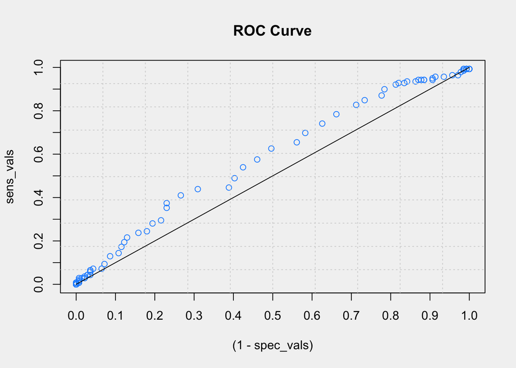

```r
calc_roc(full_step_aic, divisions = 200, plot = TRUE)
```

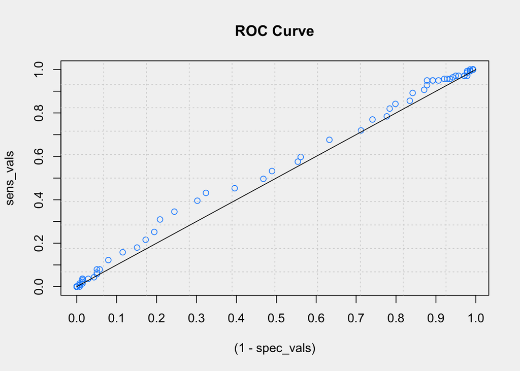

```r
calc_roc(glm4, divisions = 200, plot = TRUE)
```

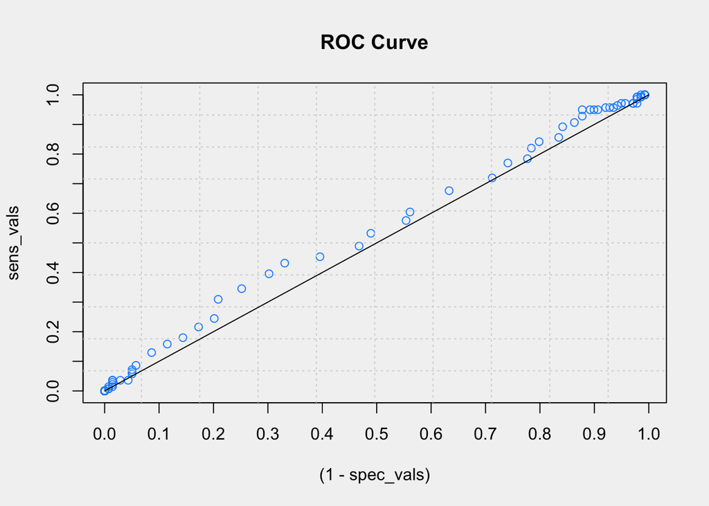

```r
calc_roc(glm4_step_aic, divisions = 200, plot = TRUE)
```

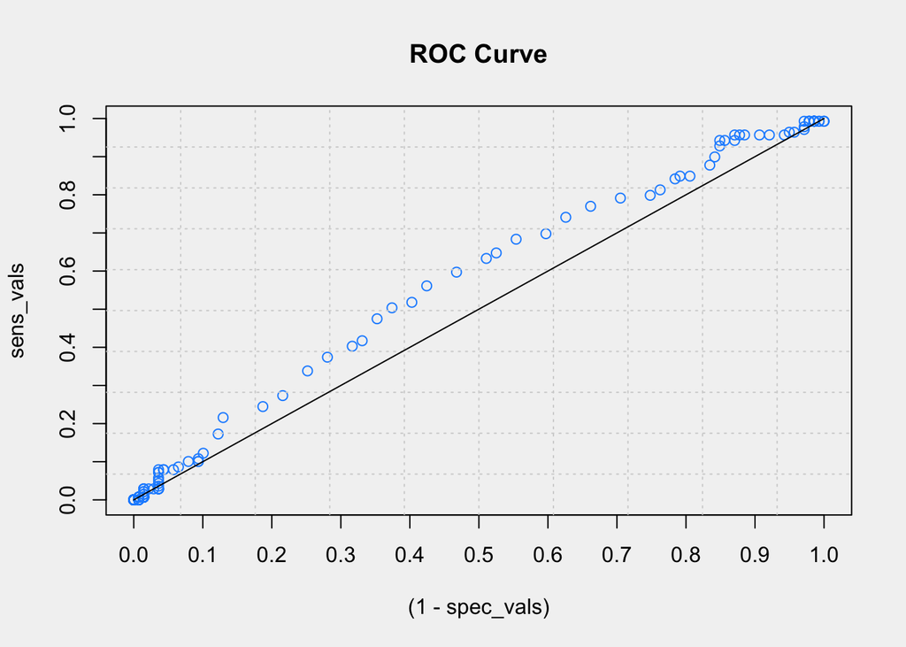

```r
calc_roc(full_int_step_aic, divisions = 200, plot = TRUE)
```

## Revaluating accuracy

Many of our models have a high sensitivity and low specificity. Sensitivity is the true positive rate and specificity is the true negative rate. Therefore, our models are much better at predicting when the price will go up versus down. Let’s see if changing the classification threshold helps improve the accuracy of these models.

Creating functions for finding the best accuracy

```r
get_acc = function(model, threshold) {
  predictions = ifelse(predict(model, BTC_test, type = 'response') > threshold, TRUE, FALSE)
  accuracy = mean(predictions == BTC_test$price_increase_next_day)
  accuracy
}
```

```r
best_acc = function(model, iterations) {
  accuracies = rep(0, times = iterations)
  thresholds = rep(0, times = iterations)
  for (i in 1:iterations) {
    thresh = i * 1 / iterations
    acc = get_acc(model, threshold = thresh)
    accuracies[i] = acc
    thresholds[i] = thresh
  }
  best_acc_ind = which.max(accuracies)
  list(Accuracy = accuracies, Threshold = thresholds, best_acc = accuracies[best_acc_ind], best_thres = thresholds[best_acc_ind])
}
```

Finding the best accuracy

```r
best_acc_full_step_aic = best_acc(full_step_aic, 100)
best_acc_glm4 = best_acc(glm4, 100)
best_acc_glm4_step_aic = best_acc(glm4_step_aic, 100)
best_acc_full_int_step_aic = best_acc(full_int_step_aic, 100)

df = data.frame(best_acc = c(best_acc_full_step_aic$best_acc, best_acc_glm4$best_acc, best_acc_glm4_step_aic$best_acc, best_acc_full_int_step_aic$best_acc),
           best_thresh = c(best_acc_full_step_aic$best_thres, best_acc_glm4$best_thres, best_acc_glm4_step_aic$best_thres, best_acc_full_int_step_aic$best_thres),
           row.names = c('full_step_aic', 'glm4', 'glm4_step_aic', 'full_int_step_aic'))
knitr::kable(df)
```

|  | best_acc | best_thresh |
| --- | --- | --- |
| full_step_aic | 0.5719424 | 0.58 |
| glm4 | 0.5539568 | 0.57 |
| glm4_step_aic | 0.5503597 | 0.57 |
| full_int_step_aic | 0.5647482 | 0.55 |

## Conclusion

Unfortunately, we were not able to find any models that could predict next-day price movement with sufficient accuracy. We know from previous workbooks that the price of bitcoin rose the next day roughly 54% of the time for this dataset. Our goal was to, at the very least, have higher accuracy than this percentage because we wanted a model that performs better than predicting `TRUE` for every single outcome. We were able to achieve this goal, but we did not beat it by much. Our best model `full_step_aic` has an accuracy of 57.19%. This is only 3.19 % higher than the 54% we wanted to beat.

Nonetheless, predicting the price of **any** crypto currency can be difficult due to the extreme volatility of the markets. With a simple google search, you can see that many people have tried and failed to predict the price of bitcoin. Others have had some success, but their models do not show consistent performance. Some people have been able to successfully predict the price of bitcoin on a very short time frame. They have even expanded these algorithms to be used for trading. However, the major issue seen with these models is that even when the algorithm can make profitable trades, the fees associated with those trades are higher than the profits themselves.

Regardless, the was a great learning experience, and I’m excited to start working on potential improvements for this model!

### Potential next steps

Some of the things I might do in the future to improve the model’s performance include:

- Using a different machine learning algorithm such as
  - Decision trees
  - Support vector machine
  - K nearest neighbors
  - Neural networks
- Boosting
- Gather more data such as
  - The bitcoin trading volume
  - The volume of tweets related to bitcoin
  - Incorporating data from different trading indicators
- Improve the sentiment analysis classification
  - We could produce better sentiment results by using our own corpus of positive and negative words commonly found in bitcoin tweets